# High_Code_Plant_Seedling_Classification

## **Plant Seedling Classification**

Bennittah Kagumya, Ngazoire

### **Context:**

In recent times, the field of agriculture has been in urgent need of modernizing, since the amount of manual work people need to put in to check if plants are growing correctly is still highly extensive. Despite several advances in agricultural technology, people working in the agricultural industry still need to have the ability to sort and recognize different plants and weeds, which takes a lot of time and effort in the long term. The potential is ripe for this trillion-dollar industry to be greatly impacted by technological innovations that cut down on the requirement for manual labor, and this is where Artificial Intelligence can actually benefit the workers in this field, as **the time and energy required to identify plant seedlings will be greatly shortened by the use of AI and Deep Learning.** The ability to do so far more efficiently and even more effectively than experienced manual labor, could lead to better crop yields, the freeing up of human inolvement for higher-order agricultural decision making, and in the long term will result in more sustainable environmental practices in agriculture as well.

### **Objective:**

The aim of this project is to **Build a Convolutional Neural Netowrk to classify plant seedlings into their respective categories.**

### **Data Description:**

The Aarhus University Signal Processing group, in collaboration with the University of Southern Denmark, has recently released a dataset containing **images of unique plants belonging to 12 different species.**

- The dataset can be download from Olympus.
- The data file names are:
  - images.npy
  - Label.csv
- Due to the large volume of data, the images were converted to the images.npy file and the labels are also put into Labels.csv, so that you can work on the data/project seamlessly without having to worry about the high data volume.
- The goal of the project is to create a classifier capable of determining a plant's species from an image.

**List of Species**

- Black-grass
- Charlock
- Cleavers
- Common Chickweed
- Common Wheat
- Fat Hen
- Loose Silky-bent
- Maize
- Scentless Mayweed
- Shepherds Purse
- Small-flowered Cranesbill
- Sugar beet

#### **Note: Please use GPU runtime to execute the code efficiently**

### Importing necessary libraries

```python
import os
import numpy as np                                                                               # Importing numpy for Matrix Operations
import pandas as pd                                                                              # Importing pandas to read CSV files
import matplotlib.pyplot as plt                                                                  # Importting matplotlib for Plotting and visualizing images
import math                                                                                      # Importing math module to perform mathematical operations
import cv2                                                                                       # Importing openCV for image processing
import seaborn as sns                                                                            # Importing seaborn to plot graphs


# Tensorflow modules
import tensorflow as tf
from tensorflow.keras.preprocessing.image import ImageDataGenerator                              # Importing the ImageDataGenerator for data augmentation
from tensorflow.keras.models import Sequential                                                   # Importing the sequential module to define a sequential model
from tensorflow.keras.layers import Dense,Dropout,Flatten,Conv2D,MaxPooling2D,BatchNormalization # Defining all the layers to build our CNN Model
from tensorflow.keras.optimizers import Adam,SGD                                                 # Importing the optimizers which can be used in our model
from sklearn import preprocessing                                                                # Importing the preprocessing module to preprocess the data
from sklearn.model_selection import train_test_split                                             # Importing train_test_split function to split the data into train and test
from sklearn.metrics import confusion_matrix  , classification_report                            # Importing confusion_matrix to plot the confusion matrix
from tensorflow.keras.callbacks import ReduceLROnPlateau
from tensorflow.keras.regularizers import l2
# Display images using OpenCV
from google.colab.patches import cv2_imshow                                                      # Importing cv2_imshow from google.patches to display images

# Ignore warnings
import warnings
warnings.filterwarnings('ignore')
```

```python
tf.config.list_physical_devices('GPU')
```

```
[PhysicalDevice(name='/physical_device:GPU:0', device_type='GPU')]
```

### Mounting drive

```python
# Mount Google drive to access the dataset
from google.colab import drive
drive.mount('/content/drive')
```

### Read the dataset

```python
# Load the image file of dataset
images = np.load('/content/drive/MyDrive/AI/images.npy')      # Complete the code to read the dataset

# Load the labels file of dataset
labels = pd.read_csv('/content/drive/MyDrive/AI/Labels.csv')  # Complete the code to read the dataset
```

### Data Overview

- Check the shape of images and the labels in the data
- Converting images from BGR to RGB

#### Checking the shape of the dataset

```python
print(images.shape)         # Complete the code to check the shape
print(labels.shape)         # Complete the code to check the shape
```

```
(4750, 128, 128, 3)
(4750, 1)
```

#### Converting the BGR images to RGB images.

```python
# Converting the images from BGR to RGB using cvtColor function of OpenCV
for i in range(len(images)):
  images[i] = cv2.cvtColor(images[i], cv2.COLOR_BGR2RGB)        # Complete the code to convert the images from BGR to RGB
```

### Exploratory Data Analysis

- EDA is an important part of any project involving data.
- It is important to investigate and understand the data better before building a model with it.
- A few questions have been mentioned below which will help you understand the data better.
- A thorough analysis of the data, in addition to the questions mentioned below, should be done.
1. How are these different category plant images different from each other?
2. Is the dataset provided an imbalance? (Check with using bar plots)

```python
def plot_images(images,labels):
  num_classes=10                                                                  # Number of Classes
  categories=np.unique(labels)
  keys=dict(labels['Label'])                                                      # Obtaing the unique classes from y_train
  rows = 3                                                                        # Defining number of rows=3
  cols = 4                                                                        # Defining number of columns=4
  fig = plt.figure(figsize=(10, 8))                                               # Defining the figure size to 10x8
  for i in range(cols):
      for j in range(rows):
          random_index = np.random.randint(0, len(labels))                        # Generating random indices from the data and plotting the images
          ax = fig.add_subplot(rows, cols, i * rows + j + 1)                      # Adding subplots with 3 rows and 4 columns
          ax.imshow(images[random_index, :])                                      # Plotting the image
          ax.set_title(keys[random_index])
  plt.show()
```

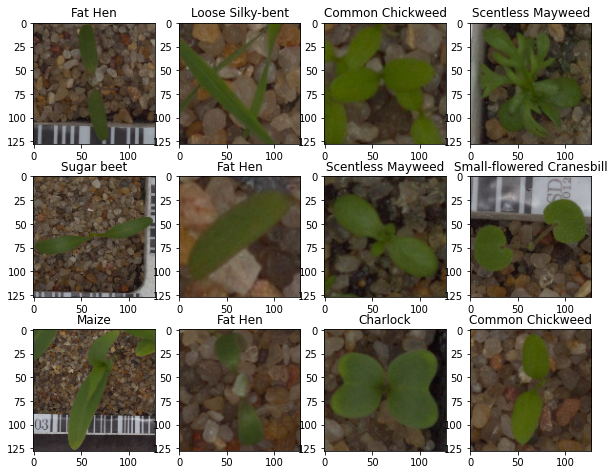

```python
plot_images(images,labels)   # Complete the code to input the images and labels to the function and plot the images with their labels
```

**Checking for data imbalance**

[output not shown]

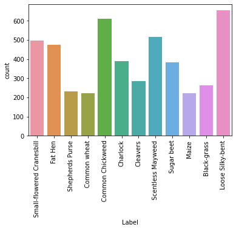

```python
# checking for data imbalance
sns.countplot(labels['Label'])
plt.xticks(rotation='vertical')
```

- We can observe that the data is somewhat imbalanced with the number of images for the loosely Silky-bent class category are somewhat more as compared to other categories. We will use appropriate evaluation methods like precision and recall to evaluate the model.

### Resizing images

As the size of the images is large, it may be computationally expensive to train on these larger images; therefore, it is preferable to reduce the image size from 128 to 64.

```python
images_decreased=[]
height = 64                    # Complete the code to define the height as 64
width =  64                    # Complete the code to define the width as 64
dimensions = (width, height)
for i in range(len(images)):
  images_decreased.append( cv2.resize(images[i], dimensions, interpolation=cv2.INTER_LINEAR))
```

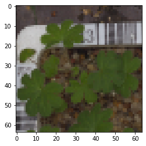

```python
plt.imshow(images_decreased[3]);
```

```python
# Applying Gaussian Blur to denoise the images
images_gb=[]
for i in range(len(images)):
  # gb[i] = cv2.cvtColor(images[i], cv2.COLOR_BGR2RGB)
  images_gb.append(cv2.GaussianBlur(images[i], ksize =(3,3),sigmaX =  0))
```

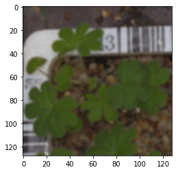

```python
plt.imshow(images_gb[3]);
```

- We observe that the image become more readable after applying Gaussian Blur to remove noise from the images

### Data Preparation for modeling

- Before you proceed to build a model, you need to split the data into train, test, and validation to be able to evaluate the model that you build on the train data
- You'll have to encode categorical features and scale the pixel values.
- You will build a model using the train data and then check its performance

#### Splitting the dataset

```python
# Let's split the data with test_size as 0.1
from sklearn.model_selection import train_test_split
X_temp, X_test, y_temp, y_test = train_test_split(np.array(images_decreased),labels , test_size=0.1, random_state=42,stratify=labels)
X_train, X_val, y_train, y_val = train_test_split(X_temp,y_temp , test_size=0.1, random_state=42,stratify=y_temp)
```

```python
print(X_train.shape,y_train.shape)
print(X_val.shape,y_val.shape)
print(X_test.shape,y_test.shape)
```

```
(3847, 64, 64, 3) (3847, 1)
(428, 64, 64, 3) (428, 1)
(475, 64, 64, 3) (475, 1)
```

```python
#%%capture class_weights
#Treating Class Imbalance
from sklearn.utils import class_weight

labelList = labels.Label.unique()
class_weights = class_weight.compute_class_weight(class_weight = "balanced",
                                                  classes = np.array(labelList),
                                                  y = y_train.values.reshape(-1)
                                                  )
class_weights = dict(zip(np.array(range(len(labelList))), class_weights))
#print(calculated class weights)
class_weights
```

```
{0: 0.7974709784411277,
 1: 0.8348524305555556,
 2: 1.714349376114082,
 3: 1.7909683426443204,
 4: 0.6476430976430977,
 5: 1.0145042194092826,
 6: 1.3818247126436782,
 7: 0.7669457735247209,
 8: 1.0275106837606838,
 9: 1.7909683426443204,
 10: 1.5050860719874803,
 11: 0.604874213836478}
```

#### Encoding the target labels

```python
# Converting labels from names to one hot vectors using labelBinarizer.

from sklearn.preprocessing import LabelBinarizer
enc = LabelBinarizer()
y_train_encoded = enc.fit_transform(y_train)
y_val_encoded=enc.transform(y_val)
y_test_encoded=enc.transform(y_test)
```

```python
enc.classes_
```

```
array(['Black-grass', 'Charlock', 'Cleavers', 'Common Chickweed',
       'Common wheat', 'Fat Hen', 'Loose Silky-bent', 'Maize',
       'Scentless Mayweed', 'Shepherds Purse',
       'Small-flowered Cranesbill', 'Sugar beet'], dtype='<U25')
```

```python
# Lets check the shape of train, validation and test data
y_train_encoded.shape, y_val_encoded.shape, y_test_encoded.shape
```

```
((3847, 12), (428, 12), (475, 12))
```

#### Data Normalization (Scaling)

```python
# Normalizing the image pixels of train, validation data and test data
X_train_normalized = X_train.astype('float32')/255.0
X_val_normalized = X_val.astype('float32')/255.0
X_test_normalized = X_test.astype('float32')/255.0
```

### Model Building - Convolutional Neural Network (CNN)

First, we need to clear the previous model's history from the session even if a single model can run multiple times on the same data.

In Keras, we need a special command to clear the model's history, otherwise the previous model history remains in the backend.

Also, let's fix the seed again after clearing the backend.

Let's **set the seed for random number generators in Numpy, the Random library in Python, and in TensorFlow** to be able to reproduce the same results every time we run the code.

#### Clearing the backend session and initializing the random seed values

```python
# Clearing backend
from tensorflow.keras import backend
backend.clear_session()
```

```python
# We fix the seed for random number generators
import random
np.random.seed(42)
random.seed(42)
tf.random.set_seed(42)
```

### Model Buidling (CNN)

We build a CNN Model with Feature Extraction layers comprised of convolutional and pooling layers, and Fully Connected classification layers for prediction.

```python
# Intializing a sequential model
model = Sequential()

# Adding first conv layer with 64 filters and kernel size 3x3 , padding 'same' provides the output size same as the input size
# Input_shape denotes input image dimension of images
model.add(Conv2D(64, (3, 3), activation='relu', padding="same", input_shape=(64, 64, 3)))

# Adding max pooling to reduce the size of output of first conv layer
model.add(MaxPooling2D((2, 2), padding = 'same'))

model.add(Conv2D(32, (3, 3), activation='relu', padding="same"))
model.add(MaxPooling2D((2, 2), padding = 'same'))

# flattening the output of the conv layer after max pooling to make it ready for creating dense connections
model.add(Flatten())

# Adding a fully connected dense layer with 16 neurons
model.add(Dense(16, activation='relu'))
model.add(Dropout(0.3))
# Adding the output layer with 12 neurons and activation functions as softmax since this is a multi-class classification problem
model.add(Dense(12, activation='softmax'))

opt=Adam()
# Compile model
model.compile(optimizer=opt, loss='categorical_crossentropy', metrics=['accuracy'])
```

#### Summary of the model

```python
# Generating the summary of the model
model.summary()
```

```
Model: "sequential"
_________________________________________________________________
 Layer (type)                Output Shape              Param #
=================================================================
 conv2d (Conv2D)             (None, 64, 64, 64)        1792

 max_pooling2d (MaxPooling2D  (None, 32, 32, 64)       0
 )

 conv2d_1 (Conv2D)           (None, 32, 32, 32)        18464

 max_pooling2d_1 (MaxPooling  (None, 16, 16, 32)       0
 2D)

 flatten (Flatten)           (None, 8192)              0

 dense (Dense)               (None, 16)                131088

 dropout (Dropout)           (None, 16)                0

 dense_1 (Dense)             (None, 12)                204

=================================================================
Total params: 151,548
Trainable params: 151,548
Non-trainable params: 0
_________________________________________________________________
```

#### Fitting the model on the train data

```python
# Let's fit the model on train and use the validation data for validation of the model
history = model.fit(
            X_train_normalized, y_train_encoded,
            epochs=30,
            validation_data=(X_val_normalized,y_val_encoded),
            batch_size=32,
            verbose=2
)
```

```
121/121 - 11s - loss: 2.4504 - accuracy: 0.1282 - val_loss: 2.3784 - val_accuracy: 0.1425 - 11s/epoch - 93ms/step
121/121 - 1s - loss: 2.2840 - accuracy: 0.1890 - val_loss: 2.1142 - val_accuracy: 0.2664 - 1s/epoch - 8ms/step
121/121 - 1s - loss: 2.0684 - accuracy: 0.2410 - val_loss: 1.8995 - val_accuracy: 0.3435 - 715ms/epoch - 6ms/step
121/121 - 1s - loss: 1.9540 - accuracy: 0.2729 - val_loss: 1.7970 - val_accuracy: 0.3505 - 744ms/epoch - 6ms/step
121/121 - 1s - loss: 1.9141 - accuracy: 0.2813 - val_loss: 1.7199 - val_accuracy: 0.3692 - 712ms/epoch - 6ms/step
121/121 - 1s - loss: 1.8757 - accuracy: 0.2867 - val_loss: 1.7078 - val_accuracy: 0.3832 - 720ms/epoch - 6ms/step
121/121 - 1s - loss: 1.8476 - accuracy: 0.2896 - val_loss: 1.6853 - val_accuracy: 0.3832 - 719ms/epoch - 6ms/step
121/121 - 1s - loss: 1.8279 - accuracy: 0.3073 - val_loss: 1.6265 - val_accuracy: 0.4089 - 717ms/epoch - 6ms/step
121/121 - 1s - loss: 1.8235 - accuracy: 0.3031 - val_loss: 1.6427 - val_accuracy: 0.4299 - 737ms/epoch - 6ms/step
121/121 - 1s - loss: 1.7976 - accuracy: 0.3231 - val_loss: 1.6407 - val_accuracy: 0.4159 - 726ms/epoch - 6ms/step
121/121 - 1s - loss: 1.8003 - accuracy: 0.3189 - val_loss: 1.6551 - val_accuracy: 0.4229 - 720ms/epoch - 6ms/step
121/121 - 1s - loss: 1.8000 - accuracy: 0.3156 - val_loss: 1.6117 - val_accuracy: 0.4626 - 725ms/epoch - 6ms/step
121/121 - 1s - loss: 1.7783 - accuracy: 0.3397 - val_loss: 1.5711 - val_accuracy: 0.4603 - 951ms/epoch - 8ms/step
121/121 - 1s - loss: 1.7621 - accuracy: 0.3353 - val_loss: 1.5577 - val_accuracy: 0.4626 - 900ms/epoch - 7ms/step
121/121 - 1s - loss: 1.7357 - accuracy: 0.3444 - val_loss: 1.5894 - val_accuracy: 0.4603 - 871ms/epoch - 7ms/step
121/121 - 1s - loss: 1.7242 - accuracy: 0.3551 - val_loss: 1.5089 - val_accuracy: 0.4860 - 862ms/epoch - 7ms/step
121/121 - 1s - loss: 1.6898 - accuracy: 0.3704 - val_loss: 1.5100 - val_accuracy: 0.5257 - 729ms/epoch - 6ms/step
121/121 - 1s - loss: 1.7010 - accuracy: 0.3665 - val_loss: 1.4488 - val_accuracy: 0.4766 - 721ms/epoch - 6ms/step
121/121 - 1s - loss: 1.6905 - accuracy: 0.3738 - val_loss: 1.4608 - val_accuracy: 0.5023 - 752ms/epoch - 6ms/step
121/121 - 1s - loss: 1.6654 - accuracy: 0.3787 - val_loss: 1.4716 - val_accuracy: 0.4883 - 731ms/epoch - 6ms/step
121/121 - 1s - loss: 1.6495 - accuracy: 0.3800 - val_loss: 1.5477 - val_accuracy: 0.4579 - 724ms/epoch - 6ms/step
121/121 - 1s - loss: 1.6433 - accuracy: 0.3871 - val_loss: 1.4464 - val_accuracy: 0.4930 - 738ms/epoch - 6ms/step
121/121 - 1s - loss: 1.6461 - accuracy: 0.3845 - val_loss: 1.4891 - val_accuracy: 0.5374 - 726ms/epoch - 6ms/step
121/121 - 1s - loss: 1.6386 - accuracy: 0.3907 - val_loss: 1.4618 - val_accuracy: 0.4907 - 752ms/epoch - 6ms/step
121/121 - 1s - loss: 1.6216 - accuracy: 0.4027 - val_loss: 1.3883 - val_accuracy: 0.5164 - 735ms/epoch - 6ms/step
121/121 - 1s - loss: 1.5974 - accuracy: 0.4097 - val_loss: 1.3886 - val_accuracy: 0.5234 - 744ms/epoch - 6ms/step
121/121 - 1s - loss: 1.6029 - accuracy: 0.3977 - val_loss: 1.3999 - val_accuracy: 0.5327 - 742ms/epoch - 6ms/step
121/121 - 1s - loss: 1.5787 - accuracy: 0.4164 - val_loss: 1.3933 - val_accuracy: 0.5234 - 720ms/epoch - 6ms/step
121/121 - 1s - loss: 1.5771 - accuracy: 0.4063 - val_loss: 1.3969 - val_accuracy: 0.5070 - 736ms/epoch - 6ms/step
121/121 - 1s - loss: 1.5959 - accuracy: 0.4042 - val_loss: 1.3917 - val_accuracy: 0.5210 - 918ms/epoch - 8ms/step
```

#### Model Evaluation

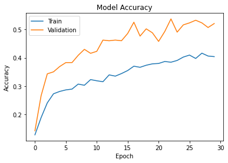

```python
# Model Evaluation
plt.plot(history.history['accuracy'])
plt.plot(history.history['val_accuracy'])
plt.title('Model Accuracy')
plt.ylabel('Accuracy')
plt.xlabel('Epoch')
plt.legend(['Train', 'Validation'], loc='upper left')
plt.show()
```

Let's check the model performance on test set.

#### Evaluating the model on test data

```python
accuracy = model.evaluate(X_test_normalized, y_test_encoded, verbose=2)
```

```
15/15 - 0s - loss: 1.3883 - accuracy: 0.5284 - 148ms/epoch - 10ms/step
```

```python
# Getting the output as probablities for each category
y_pred=model.predict(X_test_normalized)
```

```python
y_pred
```

```
array([[8.49529891e-11, 1.11195709e-06, 3.29045506e-05, ...,
        2.52558663e-02, 7.19555260e-07, 1.94003864e-04],
       [2.63928086e-07, 9.63861530e-04, 6.06607832e-03, ...,
        1.18032014e-02, 9.18045044e-01, 4.76714931e-02],
       [1.56558803e-04, 6.14431687e-04, 1.93598308e-02, ...,
        1.10554425e-02, 7.56338656e-01, 1.22808054e-01],
       ...,
       [2.22217217e-01, 2.17635744e-07, 1.11446025e-04, ...,
        7.83140841e-09, 1.29652756e-06, 4.14751761e-04],
       [3.57946497e-03, 1.97413620e-02, 5.94782755e-02, ...,
        8.07554722e-02, 9.73497424e-03, 8.62011835e-02],
       [6.12989752e-05, 9.49487370e-03, 4.89644557e-02, ...,
        6.51516020e-02, 5.40567100e-01, 1.94478184e-01]], dtype=float32)
```

#### Plot the Confusion Matrix

- The Confusion matrix is also defined as an inbuilt function in the TensorFlow module, so we can use that for evaluating the classification model.
- The Confusion matrix expects categorical data as input. However, y_test_encoded is an encoded value, whereas y_pred has probabilities. So,we must retrieve the categorical values from the encoded values.
- We will use the `argmax()` function to obtain the maximum value over each category on both y_test_encoded and y_pred and obtain their respective classes.

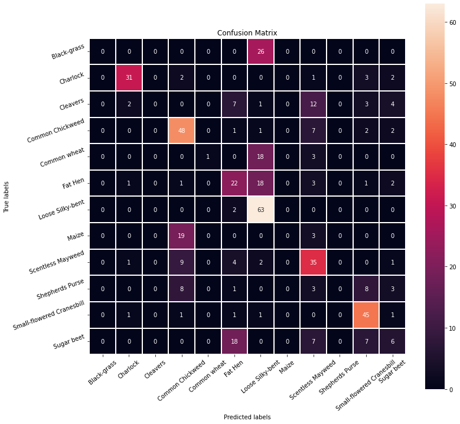

```python
# Let's obtain the categorical values from y_test_encoded and y_pred
y_pred_arg=np.argmax(y_pred,axis=1)
y_test_arg=np.argmax(y_test_encoded,axis=1)

# Now we plot the Confusion Matrix using the tensorflow confusion matrix() function
confusion_matrix = tf.math.confusion_matrix(y_test_arg,y_pred_arg)
f, ax = plt.subplots(figsize=(12, 12))
sns.heatmap(
    confusion_matrix,
    annot=True,
    linewidths=.4,
    fmt="d",
    square=True,
    ax=ax
)

# Let's set the labels to both the axes
ax.set_xlabel('Predicted labels');ax.set_ylabel('True labels');
ax.set_title('Confusion Matrix');
ax.xaxis.set_ticklabels(list(enc.classes_),rotation=40)
ax.yaxis.set_ticklabels(list(enc.classes_),rotation=20)
plt.show()
```

**Observations**: We observe that some of the classes are not predicted correctly. Loosely silky-bent is being confused with black grass, common wheat and Fat hen for instance. Most of the classes are mostly misclassified.

#### Plot Classification Report

```python
# Plotting the classification report
cr = classification_report(y_test_arg, y_pred_arg)
print(cr)
```

```
              precision    recall  f1-score   support

           0       0.00      0.00      0.00        26
           1       0.86      0.79      0.83        39
           2       0.00      0.00      0.00        29
           3       0.55      0.79      0.64        61
           4       1.00      0.05      0.09        22
           5       0.39      0.46      0.42        48
           6       0.48      0.97      0.65        65
           7       0.00      0.00      0.00        22
           8       0.47      0.67      0.56        52
           9       0.00      0.00      0.00        23
          10       0.65      0.90      0.76        50
          11       0.29      0.16      0.20        38

    accuracy                           0.53       475
   macro avg       0.39      0.40      0.35       475
weighted avg       0.44      0.53      0.44       475
```

### Deleting the model and history variable to use the RAM efficiently

```python
del model
del history   # Complete the code to delete the history_1 variable
```

# **Improving the Base Model using Data Augmentation and Regularization**

**Reducing the Learning Rate:**

**Hint**: Use **ReduceLRonPlateau()** function that will be used to decrease the learning rate by some factor, if the loss is not decreasing for some time. This may start decreasing the loss at a smaller learning rate. There is a possibility that the loss may still not decrease. This may lead to executing the learning rate reduction again in an attempt to achieve a lower loss.

```python
from keras.callbacks import ReduceLROnPlateau

# monitoring val_accuracy
learning_rate_reduction = ReduceLROnPlateau(monitor='val_accuracy',
                                            patience=3,
                                            verbose=1,
                                            factor=0.5,
                                            min_lr=0.00001)
```

### **Data Augmentation**

Remember, **data augmentation should not be used in the validation/test data set**.

#### Clearing the backend session and initializing the random seed values

```python
# Clearing backend
from tensorflow.keras import backend
backend.clear_session()

# Fixing the seed for random number generators
import random
np.random.seed(42)
random.seed(42)
tf.random.set_seed(42)
```

```python
# Let's set the rotation_range to 20   # All images to be rescaled by 1/255.
train_datagen = ImageDataGenerator(
                              rotation_range=20,
                              fill_mode='nearest'
                              )

# test_datagen  = ImageDataGenerator(rescale = 1.0/255.)
```

### Model Buidling - Model1

```python
# Intializing a sequential model
model1 = Sequential()

# Adding first conv layer with 64 filters and kernel size 3x3 , padding 'same' provides the output size same as the input size
# Input_shape denotes input image dimension of images
model1.add(Conv2D(64, (3, 3), activation='relu', padding="same", input_shape=(64, 64, 3)))
# Adding max pooling to reduce the size of output of first conv layer
model1.add(MaxPooling2D((2, 2), padding = 'same'))

model1.add(Conv2D(32, (3, 3), activation='relu', padding="same"))
model1.add(MaxPooling2D((2, 2), padding = 'same'))
model1.add(BatchNormalization())
model1.add(Dropout(0.3))
# flattening the output of the conv layer after max pooling to make it ready for creating dense connections
model1.add(Flatten())

# Adding a fully connected dense layer with 16 neurons
model1.add(Dense(16, activation='relu'))
model1.add(BatchNormalization())
model1.add(Dropout(0.3))
# Adding the output layer with 12 neurons and activation functions as softmax since this is a multi-class classification problem
model1.add(Dense(12, activation='softmax'))

opt=Adam()
# Compile model
model1.compile(optimizer=opt, loss='categorical_crossentropy', metrics=['accuracy'])
```

#### Summary of the model

```python
model1.summary()
```

```
Model: "sequential"
_________________________________________________________________
 Layer (type)                Output Shape              Param #
=================================================================
 conv2d (Conv2D)             (None, 64, 64, 64)        1792

 max_pooling2d (MaxPooling2D  (None, 32, 32, 64)       0
 )

 conv2d_1 (Conv2D)           (None, 32, 32, 32)        18464

 max_pooling2d_1 (MaxPooling  (None, 16, 16, 32)       0
 2D)

 batch_normalization (BatchN  (None, 16, 16, 32)       128
 ormalization)

 dropout (Dropout)           (None, 16, 16, 32)        0

 flatten (Flatten)           (None, 8192)              0

 dense (Dense)               (None, 16)                131088

 batch_normalization_1 (Batc  (None, 16)               64
 hNormalization)

 dropout_1 (Dropout)         (None, 16)                0

 dense_1 (Dense)             (None, 12)                204

=================================================================
Total params: 151,740
Trainable params: 151,644
Non-trainable params: 96
_________________________________________________________________
```

#### Fitting the model on the train data

```python
# Let's fit the model on train data with batch_size=64 and 50 epochs
# Epochs
epochs = 50
# Batch size
batch_size = 64

history1 = model1.fit(train_datagen.flow(X_train_normalized,y_train_encoded,
                                       batch_size=batch_size,
                                       shuffle=False),
                                       epochs=epochs,
                                       steps_per_epoch=X_train_normalized.shape[0] // batch_size,
                                       validation_data=(X_val_normalized,y_val_encoded),
                                       verbose=1,callbacks=[learning_rate_reduction])
```

```
Epoch 12: ReduceLROnPlateau reducing learning rate to 0.0005000000237487257.
Epoch 15: ReduceLROnPlateau reducing learning rate to 0.0002500000118743628.
Epoch 21: ReduceLROnPlateau reducing learning rate to 0.0001250000059371814.
Epoch 27: ReduceLROnPlateau reducing learning rate to 6.25000029685907e-05.
Epoch 30: ReduceLROnPlateau reducing learning rate to 3.125000148429535e-05.
Epoch 33: ReduceLROnPlateau reducing learning rate to 1.5625000742147677e-05.
Epoch 36: ReduceLROnPlateau reducing learning rate to 1e-05.
```

#### Model Evaluation

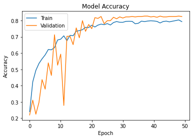

```python
plt.plot(history1.history['accuracy'])
plt.plot(history1.history['val_accuracy'])
plt.title('Model Accuracy')
plt.ylabel('Accuracy')
plt.xlabel('Epoch')
plt.legend(['Train', 'Validation'], loc='upper left')
plt.show()
```

#### Evaluating the model on test data

```python
accuracy = model1.evaluate(X_test_normalized, y_test_encoded, verbose=2)
```

```
15/15 - 0s - loss: 0.6399 - accuracy: 0.8126 - 76ms/epoch - 5ms/step
```

```python
# Getting the output as probablities for each category
y_pred=model1.predict(X_test_normalized)
```

```python
y_pred
```

```
array([[9.6166172e-05, 2.7831539e-04, 2.7622000e-05, ..., 4.6604881e-03,
        1.2664129e-04, 3.1784573e-03],
       [4.9188762e-05, 1.5344884e-02, 1.4298717e-03, ..., 3.6676284e-02,
        9.4366401e-01, 7.4598863e-04],
       [1.4069389e-03, 6.6892211e-03, 9.6614026e-03, ..., 2.7406104e-02,
        9.3795353e-01, 9.7491511e-04],
       ...,
       [2.9133466e-01, 1.9664299e-03, 9.7075421e-03, ..., 4.1884641e-04,
        2.0759450e-03, 6.7159259e-03],
       [6.5669167e-04, 1.4742648e-03, 3.9302534e-03, ..., 4.6062324e-02,
        9.7656308e-04, 4.9010459e-03],
       [1.6330531e-03, 2.4773275e-02, 2.5425029e-01, ..., 4.9465039e-01,
        1.0764292e-01, 2.7368243e-03]], dtype=float32)
```

#### Plotting the Confusion Matrix

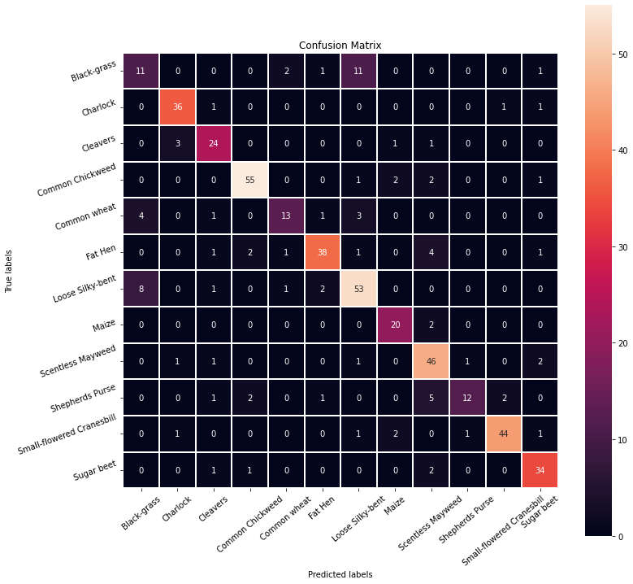

```python
# Obtaining the categorical values from y_test_encoded and y_pred
y_pred_arg=np.argmax(y_pred,axis=1)
y_test_arg=np.argmax(y_test_encoded,axis=1)

# Let's Plot the Confusion Matrix using confusion matrix() function, a predefined tensorflow module
confusion_matrix = tf.math.confusion_matrix(y_test_arg,y_pred_arg)
f, ax = plt.subplots(figsize=(12, 12))
sns.heatmap(
    confusion_matrix,
    annot=True,
    linewidths=.4,
    fmt="d",
    square=True,
    ax=ax
)

# Setting the labels to both the axes
ax.set_xlabel('Predicted labels');ax.set_ylabel('True labels');
ax.set_title('Confusion Matrix');
ax.xaxis.set_ticklabels(list(enc.classes_),rotation=40)
ax.yaxis.set_ticklabels(list(enc.classes_),rotation=20)
plt.show()
```

**Observation:**

- The confusion matrix although still has mispredictions is much improved . The model still highly confuses loose Silky bent seedlings with Black grass seedlings but over all a much lower rate of mispreditions.

#### Plot Classification Report

```python
# Plotting the classification report
cr = classification_report(y_test_arg, y_pred_arg)
print(cr)
```

```
              precision    recall  f1-score   support

           0       0.48      0.42      0.45        26
           1       0.88      0.92      0.90        39
           2       0.77      0.83      0.80        29
           3       0.92      0.90      0.91        61
           4       0.76      0.59      0.67        22
           5       0.88      0.79      0.84        48
           6       0.75      0.82      0.78        65
           7       0.80      0.91      0.85        22
           8       0.74      0.88      0.81        52
           9       0.86      0.52      0.65        23
          10       0.94      0.88      0.91        50
          11       0.83      0.89      0.86        38

    accuracy                           0.81       475
   macro avg       0.80      0.78      0.78       475
weighted avg       0.81      0.81      0.81       475
```

**Observations**:

### Visualizing the prediction

```
Predicted Label ['Small-flowered Cranesbill']
True Label Small-flowered Cranesbill
```

```
Predicted Label ['Cleavers']
True Label Cleavers
```

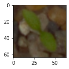

```
Predicted Label ['Common Chickweed']
True Label Common Chickweed
```

```
Predicted Label ['Shepherds Purse']
True Label Shepherds Purse
```

```python
# Visualizing the predicted and correct label of images from test data
plt.figure(figsize=(2,2))
plt.imshow(X_test[2])
plt.show()
print('Predicted Label', enc.inverse_transform(model1.predict((X_test_normalized[2].reshape(1,64,64,3)))))   # reshaping the input image as we are only trying to predict using a single image
print('True Label', enc.inverse_transform(y_test_encoded)[2])                                               # using inverse_transform() to get the output label from the output vector

plt.figure(figsize=(2,2))
plt.imshow(X_test[33])
plt.show()
print('Predicted Label', enc.inverse_transform(model1.predict((X_test_normalized[33].reshape(1,64,64,3)))))  # reshaping the input image as we are only trying to predict using a single image
print('True Label', enc.inverse_transform(y_test_encoded)[33])                                              # using inverse_transform() to get the output label from the output vector

plt.figure(figsize=(2,2))
plt.imshow(X_test[59],)
plt.show()
print('Predicted Label', enc.inverse_transform(model1.predict((X_test_normalized[59].reshape(1,64,64,3)))))  # reshaping the input image as we are only trying to predict using a single image
print('True Label', enc.inverse_transform(y_test_encoded)[59])                                              # using inverse_transform() to get the output label from the output vector

plt.figure(figsize=(2,2))
plt.imshow(X_test[36])
plt.show()
print('Predicted Label', enc.inverse_transform(model1.predict((X_test_normalized[36].reshape(1,64,64,3)))))  # reshaping the input image as we are only trying to predict using a single image
print('True Label', enc.inverse_transform(y_test_encoded)[36])                                              # using inverse_transform() to get the output label from the output vector
```

**Observations**

- We observe that all the above images were classified correctly. This shows that data augmentation has helped in creating a generalized model.

### Deleting the model and history variable to use the RAM efficiently

```python
del model1
del history1   # Complete the code to delete the history_1 variable
```

```python
from keras.callbacks import ReduceLROnPlateau

# monitoring val_accuracy
learning_rate_reduction = ReduceLROnPlateau(monitor='val_accuracy',
                                            patience=3,
                                            verbose=1,
                                            factor=0.5,
                                            min_lr=0.00001)
```

### Model Buidling - 3

Let's try a different architecture, increase the rotation range for ImageDataGenerator to 30 and see if there we get even better accuracy.

```python
# Clearing backend
from tensorflow.keras import backend
backend.clear_session()

# Fixing the seed for random number generators
import random
np.random.seed(42)
random.seed(42)
tf.random.set_seed(42)
```

```python
# All images to be rescaled by 1/255.
#train_datagen = ImageDataGenerator(
#                              rotation_range=20,
#                              fill_mode='nearest'
#                             )
# test_datagen  = ImageDataGenerator(rescale = 1.0/255.)
```

```python
train_datagen = ImageDataGenerator(
                               rotation_range = 30,
                               zoom_range = 0.1,
                               width_shift_range = 0.1,
                               height_shift_range = 0.1,
                               horizontal_flip = True,
                               vertical_flip = True,
                               fill_mode = 'nearest')
```

```python
# Intializing a sequential model
model2 = Sequential()

# Adding first conv layer with 32 filters and kernel size 3x3, padding 'same' provides the output size same as the input size
# Input_shape denotes input image dimension images
model2.add(Conv2D(32, (3, 3), activation='relu', padding="same", input_shape=(64, 64, 3)))

# Adding max pooling to reduce the size of output of first conv layer
model2.add(MaxPooling2D((2, 2), padding = 'same'))
model2.add(BatchNormalization())
model2.add(Dropout(0.25))

# Adding another conv layer with 64 filters and kernel size 3x3
model2.add(Conv2D(64, (3, 3), activation='relu', padding="same"))
model2.add(MaxPooling2D((2, 2), padding = 'same'))
model2.add(Dropout(0.25))

# Adding another conv layer with 128 filters and kernel size 3x3
model2.add(Conv2D(128, (3, 3), activation='relu', padding="same"))
model2.add(MaxPooling2D((2, 2), padding = 'same'))
model2.add(Dropout(0.25))

# flattening the output of the conv layer after max pooling to make it ready for creating dense connections
model2.add(Flatten())

# Adding a fully connected dense layer with 256 neurons
model2.add(Dense(256, activation='relu'))
model2.add(BatchNormalization())
model2.add(Dropout(0.5))

# Adding another fully connected dense layer with 128 neurons
model2.add(Dense(128, activation='relu'))
model2.add(BatchNormalization())
model2.add(Dropout(0.5))

# Adding the output layer with 3 neurons and activation functions as softmax since this is a multi-class classification problem
model2.add(Dense(12, activation='softmax'))

# Using Adam Optimizer
opt = Adam(learning_rate=0.001)
# Compile model
model2.compile(optimizer=opt, loss='categorical_crossentropy', metrics=['accuracy'])

# Generating the summary of the model
model2.summary()
```

```
Model: "sequential"
_________________________________________________________________
 Layer (type)                Output Shape              Param #
=================================================================
 conv2d (Conv2D)             (None, 64, 64, 32)        896

 max_pooling2d (MaxPooling2D  (None, 32, 32, 32)       0
 )

 batch_normalization (BatchN  (None, 32, 32, 32)       128
 ormalization)

 dropout (Dropout)           (None, 32, 32, 32)        0

 conv2d_1 (Conv2D)           (None, 32, 32, 64)        18496

 max_pooling2d_1 (MaxPooling  (None, 16, 16, 64)       0
 2D)

 dropout_1 (Dropout)         (None, 16, 16, 64)        0

 conv2d_2 (Conv2D)           (None, 16, 16, 128)       73856

 max_pooling2d_2 (MaxPooling  (None, 8, 8, 128)        0
 2D)

 dropout_2 (Dropout)         (None, 8, 8, 128)         0

 flatten (Flatten)           (None, 8192)              0

 dense (Dense)               (None, 256)               2097408

 batch_normalization_1 (Batc  (None, 256)              1024
 hNormalization)

 dropout_3 (Dropout)         (None, 256)               0

 dense_1 (Dense)             (None, 128)               32896

 batch_normalization_2 (Batc  (None, 128)              512
 hNormalization)

 dropout_4 (Dropout)         (None, 128)               0

 dense_2 (Dense)             (None, 12)                1548

=================================================================
Total params: 2,226,764
Trainable params: 2,225,932
Non-trainable params: 832
_________________________________________________________________
```

```python
# Epochs
epochs = 50
# Batch size
batch_size = 64

history2 = model2.fit(train_datagen.flow(X_train_normalized,y_train_encoded,
                                       batch_size=batch_size,
                                       seed=42,
                                       shuffle=False),
                    epochs=epochs,
                    steps_per_epoch=X_train_normalized.shape[0] // batch_size,
                    validation_data=(X_val_normalized,y_val_encoded),
                    verbose=2)
```

```
60/60 - 10s - loss: 2.8312 - accuracy: 0.2162 - val_loss: 4.8841 - val_accuracy: 0.1379 - 10s/epoch - 168ms/step
60/60 - 6s - loss: 2.0576 - accuracy: 0.3442 - val_loss: 8.8755 - val_accuracy: 0.1379 - 6s/epoch - 95ms/step
60/60 - 5s - loss: 1.6801 - accuracy: 0.4555 - val_loss: 9.9241 - val_accuracy: 0.1379 - 5s/epoch - 83ms/step
60/60 - 5s - loss: 1.4783 - accuracy: 0.5075 - val_loss: 10.1707 - val_accuracy: 0.1379 - 5s/epoch - 79ms/step
60/60 - 6s - loss: 1.3543 - accuracy: 0.5385 - val_loss: 10.5537 - val_accuracy: 0.1379 - 6s/epoch - 101ms/step
60/60 - 5s - loss: 1.2611 - accuracy: 0.5813 - val_loss: 9.7932 - val_accuracy: 0.1379 - 5s/epoch - 86ms/step
60/60 - 6s - loss: 1.1582 - accuracy: 0.6032 - val_loss: 10.1044 - val_accuracy: 0.1379 - 6s/epoch - 94ms/step
60/60 - 5s - loss: 1.1912 - accuracy: 0.5927 - val_loss: 7.7124 - val_accuracy: 0.1379 - 5s/epoch - 77ms/step
60/60 - 6s - loss: 1.1366 - accuracy: 0.6056 - val_loss: 4.0322 - val_accuracy: 0.1682 - 6s/epoch - 102ms/step
60/60 - 5s - loss: 1.1355 - accuracy: 0.6233 - val_loss: 2.9997 - val_accuracy: 0.2009 - 5s/epoch - 78ms/step
60/60 - 5s - loss: 1.0425 - accuracy: 0.6371 - val_loss: 2.2242 - val_accuracy: 0.2757 - 5s/epoch - 78ms/step
60/60 - 6s - loss: 0.9950 - accuracy: 0.6672 - val_loss: 3.1000 - val_accuracy: 0.2757 - 6s/epoch - 95ms/step
60/60 - 5s - loss: 1.0051 - accuracy: 0.6577 - val_loss: 1.2338 - val_accuracy: 0.5327 - 5s/epoch - 77ms/step
60/60 - 6s - loss: 0.9448 - accuracy: 0.6841 - val_loss: 1.0219 - val_accuracy: 0.6565 - 6s/epoch - 103ms/step
60/60 - 5s - loss: 0.8922 - accuracy: 0.7047 - val_loss: 1.5410 - val_accuracy: 0.5117 - 5s/epoch - 78ms/step
60/60 - 4s - loss: 0.8597 - accuracy: 0.7100 - val_loss: 1.3076 - val_accuracy: 0.5584 - 4s/epoch - 75ms/step
60/60 - 6s - loss: 0.8336 - accuracy: 0.7079 - val_loss: 1.9267 - val_accuracy: 0.5117 - 6s/epoch - 97ms/step
60/60 - 5s - loss: 0.8029 - accuracy: 0.7314 - val_loss: 1.0218 - val_accuracy: 0.6542 - 5s/epoch - 76ms/step
60/60 - 6s - loss: 0.7905 - accuracy: 0.7325 - val_loss: 1.0974 - val_accuracy: 0.6425 - 6s/epoch - 97ms/step
60/60 - 5s - loss: 0.7530 - accuracy: 0.7362 - val_loss: 0.8044 - val_accuracy: 0.7523 - 5s/epoch - 78ms/step
60/60 - 6s - loss: 0.7220 - accuracy: 0.7592 - val_loss: 0.8515 - val_accuracy: 0.6893 - 6s/epoch - 99ms/step
60/60 - 5s - loss: 0.6971 - accuracy: 0.7608 - val_loss: 0.8740 - val_accuracy: 0.7290 - 5s/epoch - 84ms/step
60/60 - 7s - loss: 0.6688 - accuracy: 0.7708 - val_loss: 1.5905 - val_accuracy: 0.4836 - 7s/epoch - 122ms/step
60/60 - 5s - loss: 0.6527 - accuracy: 0.7787 - val_loss: 1.2685 - val_accuracy: 0.5818 - 5s/epoch - 79ms/step
60/60 - 6s - loss: 0.6215 - accuracy: 0.7891 - val_loss: 0.6700 - val_accuracy: 0.7710 - 6s/epoch - 100ms/step
60/60 - 5s - loss: 0.6588 - accuracy: 0.7724 - val_loss: 0.5770 - val_accuracy: 0.8107 - 5s/epoch - 85ms/step
60/60 - 5s - loss: 0.5678 - accuracy: 0.8078 - val_loss: 1.9092 - val_accuracy: 0.4813 - 5s/epoch - 78ms/step
60/60 - 6s - loss: 0.5403 - accuracy: 0.8134 - val_loss: 1.2983 - val_accuracy: 0.5701 - 6s/epoch - 100ms/step
60/60 - 4s - loss: 0.5613 - accuracy: 0.8010 - val_loss: 0.7188 - val_accuracy: 0.7593 - 4s/epoch - 75ms/step
60/60 - 5s - loss: 0.5542 - accuracy: 0.8062 - val_loss: 0.7956 - val_accuracy: 0.7500 - 5s/epoch - 78ms/step
60/60 - 6s - loss: 0.5176 - accuracy: 0.8213 - val_loss: 0.6368 - val_accuracy: 0.8154 - 6s/epoch - 95ms/step
60/60 - 5s - loss: 0.5462 - accuracy: 0.8134 - val_loss: 1.6599 - val_accuracy: 0.5257 - 5s/epoch - 78ms/step
60/60 - 6s - loss: 0.4968 - accuracy: 0.8253 - val_loss: 1.3784 - val_accuracy: 0.6192 - 6s/epoch - 99ms/step
60/60 - 5s - loss: 0.5068 - accuracy: 0.8245 - val_loss: 0.5965 - val_accuracy: 0.7991 - 5s/epoch - 81ms/step
60/60 - 5s - loss: 0.4880 - accuracy: 0.8321 - val_loss: 0.8712 - val_accuracy: 0.7407 - 5s/epoch - 79ms/step
60/60 - 6s - loss: 0.4834 - accuracy: 0.8343 - val_loss: 0.5022 - val_accuracy: 0.8411 - 6s/epoch - 102ms/step
60/60 - 5s - loss: 0.4820 - accuracy: 0.8277 - val_loss: 0.7054 - val_accuracy: 0.7850 - 5s/epoch - 78ms/step
60/60 - 6s - loss: 0.4782 - accuracy: 0.8351 - val_loss: 0.7652 - val_accuracy: 0.8037 - 6s/epoch - 93ms/step
60/60 - 5s - loss: 0.4895 - accuracy: 0.8308 - val_loss: 0.5066 - val_accuracy: 0.8388 - 5s/epoch - 77ms/step
60/60 - 6s - loss: 0.4349 - accuracy: 0.8477 - val_loss: 0.4779 - val_accuracy: 0.8598 - 6s/epoch - 101ms/step
60/60 - 5s - loss: 0.4471 - accuracy: 0.8451 - val_loss: 0.3157 - val_accuracy: 0.9065 - 5s/epoch - 79ms/step
60/60 - 5s - loss: 0.4380 - accuracy: 0.8377 - val_loss: 0.6258 - val_accuracy: 0.8014 - 5s/epoch - 88ms/step
60/60 - 5s - loss: 0.4286 - accuracy: 0.8488 - val_loss: 0.5513 - val_accuracy: 0.8224 - 5s/epoch - 88ms/step
60/60 - 6s - loss: 0.4068 - accuracy: 0.8573 - val_loss: 0.4509 - val_accuracy: 0.8528 - 6s/epoch - 100ms/step
60/60 - 5s - loss: 0.4406 - accuracy: 0.8427 - val_loss: 1.5255 - val_accuracy: 0.5491 - 5s/epoch - 80ms/step
60/60 - 5s - loss: 0.4250 - accuracy: 0.8488 - val_loss: 0.3678 - val_accuracy: 0.8738 - 5s/epoch - 82ms/step
60/60 - 6s - loss: 0.4394 - accuracy: 0.8422 - val_loss: 1.5598 - val_accuracy: 0.5584 - 6s/epoch - 97ms/step
60/60 - 6s - loss: 0.4237 - accuracy: 0.8575 - val_loss: 0.6195 - val_accuracy: 0.8178 - 6s/epoch - 102ms/step
60/60 - 6s - loss: 0.4055 - accuracy: 0.8591 - val_loss: 0.4525 - val_accuracy: 0.8575 - 6s/epoch - 103ms/step
60/60 - 5s - loss: 0.3970 - accuracy: 0.8551 - val_loss: 0.7944 - val_accuracy: 0.7547 - 5s/epoch - 80ms/step
```

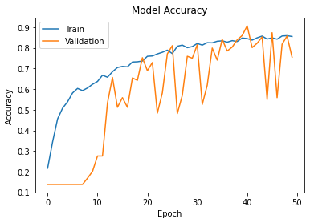

```python
plt.plot(history2.history['accuracy'])
plt.plot(history2.history['val_accuracy'])
plt.title('Model Accuracy')
plt.ylabel('Accuracy')
plt.xlabel('Epoch')
plt.legend(['Train', 'Validation'], loc='upper left')
plt.show()
```

```python
accuracy = model2.evaluate(X_test_normalized, y_test_encoded, verbose=2)
```

```
15/15 - 0s - loss: 0.7925 - accuracy: 0.7621 - 213ms/epoch - 14ms/step
```

```python
# Here we would get the output as probablities for each category
y_pred=model2.predict(X_test_normalized)
```

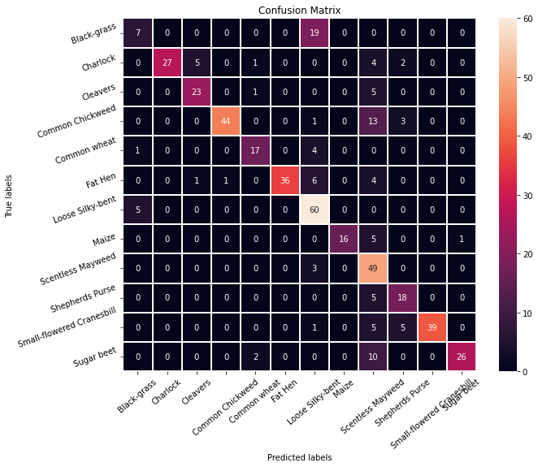

```python
# Obtaining the categorical values from y_test_encoded and y_pred
y_pred_arg=np.argmax(y_pred,axis=1)
y_test_arg=np.argmax(y_test_encoded,axis=1)

# Plotting the Confusion Matrix using confusion matrix() function which is also predefined tensorflow module
confusion_matrix = tf.math.confusion_matrix(y_test_arg,y_pred_arg)
f, ax = plt.subplots(figsize=(10, 8))
sns.heatmap(
    confusion_matrix,
    annot=True,
    linewidths=.4,
    fmt="d",
    square=True,
    ax=ax
)
# Setting the labels to both the axes
ax.set_xlabel('Predicted labels');ax.set_ylabel('True labels');
ax.set_title('Confusion Matrix');
ax.xaxis.set_ticklabels(list(enc.classes_),rotation=40)
ax.yaxis.set_ticklabels(list(enc.classes_),rotation=20)
plt.show()
```

**Observation:**

- We can observe that this model has outperformed our previousbase model but not model1. There is still some confusion particularly between Loose Silky-bent and Black grass, maize and scentless Mayweed, common Chickweed and scentless Mayweed etc

#### Plot Classification Report

```python
# Plotting the classification report
cr = classification_report(y_test_arg, y_pred_arg)
print(cr)
```

```
              precision    recall  f1-score   support

           0       0.54      0.27      0.36        26
           1       1.00      0.69      0.82        39
           2       0.79      0.79      0.79        29
           3       0.98      0.72      0.83        61
           4       0.81      0.77      0.79        22
           5       1.00      0.75      0.86        48
           6       0.64      0.92      0.75        65
           7       1.00      0.73      0.84        22
           8       0.49      0.94      0.64        52
           9       0.64      0.78      0.71        23
          10       1.00      0.78      0.88        50
          11       0.96      0.68      0.80        38

    accuracy                           0.76       475
   macro avg       0.82      0.74      0.76       475
weighted avg       0.82      0.76      0.77       475
```

**Observation:**

### Visualizing the prediction

```
Predicted Label ['Small-flowered Cranesbill']
True Label Small-flowered Cranesbill
```

```
Predicted Label ['Cleavers']
True Label Cleavers
```

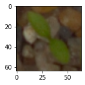

```
Predicted Label ['Common Chickweed']
True Label Common Chickweed
```

```
Predicted Label ['Shepherds Purse']
True Label Shepherds Purse
```

```python
# Visualizing the predicted and correct label of images from test data
plt.figure(figsize=(2,2))
plt.imshow(X_test[2])
plt.show()
print('Predicted Label', enc.inverse_transform(model2.predict((X_test_normalized[2].reshape(1,64,64,3)))))   # reshaping the input image as we are only trying to predict using a single image
print('True Label', enc.inverse_transform(y_test_encoded)[2])                                               # using inverse_transform() to get the output label from the output vector

plt.figure(figsize=(2,2))
plt.imshow(X_test[33])
plt.show()
print('Predicted Label', enc.inverse_transform(model2.predict((X_test_normalized[33].reshape(1,64,64,3)))))  # reshaping the input image as we are only trying to predict using a single image
print('True Label', enc.inverse_transform(y_test_encoded)[33])                                              # using inverse_transform() to get the output label from the output vector

plt.figure(figsize=(2,2))
plt.imshow(X_test[59],)
plt.show()
print('Predicted Label', enc.inverse_transform(model2.predict((X_test_normalized[59].reshape(1,64,64,3)))))  # reshaping the input image as we are only trying to predict using a single image
print('True Label', enc.inverse_transform(y_test_encoded)[59])                                              # using inverse_transform() to get the output label from the output vector

plt.figure(figsize=(2,2))
plt.imshow(X_test[36])
plt.show()
print('Predicted Label', enc.inverse_transform(model2.predict((X_test_normalized[36].reshape(1,64,64,3)))))  # reshaping the input image as we are only trying to predict using a single image
print('True Label', enc.inverse_transform(y_test_encoded)[36])                                              # using inverse_transform() to get the output label from the output vector
```

### Deleting the model and history variable to use the RAM efficiently

```python
del model2
del history2   # Complete the code to delete the history_1 variable
```

```python
from keras.callbacks import ReduceLROnPlateau

# monitoring val_accuracy
learning_rate_reduction = ReduceLROnPlateau(monitor='val_accuracy',
                                            patience=3,
                                            verbose=1,
                                            factor=0.5,
                                            min_lr=0.00001)
```

# Transfer Learning using VGG16

- Let's try again, but this time, we will be using the idea of **Transfer Learning**. We will be loading a pre-built architecture - **VGG16**, which was trained on the ImageNet dataset.
- For training VGG16, we will directly use the convolutional and pooling layers and freeze their weights i.e. no training will be done on them. For classification, we will replace the existing fully-connected layers with Fully Connected layers created specifically for our problem.

```python
# Clearing backend
from tensorflow.keras import backend
backend.clear_session()

# Fixing the seed for random number generators
import random
np.random.seed(42)
random.seed(42)
tf.random.set_seed(42)
```

```python
from tensorflow.keras.models import Model
from keras.applications.vgg16 import VGG16

vgg_model = VGG16(weights='imagenet', include_top = False, input_shape = (64,64,3))
vgg_model.summary()
```

```
Model: "vgg16"
_________________________________________________________________
 Layer (type)                Output Shape              Param #
=================================================================
 input_1 (InputLayer)        [(None, 64, 64, 3)]       0

 block1_conv1 (Conv2D)       (None, 64, 64, 64)        1792

 block1_conv2 (Conv2D)       (None, 64, 64, 64)        36928

 block1_pool (MaxPooling2D)  (None, 32, 32, 64)        0

 block2_conv1 (Conv2D)       (None, 32, 32, 128)       73856

 block2_conv2 (Conv2D)       (None, 32, 32, 128)       147584

 block2_pool (MaxPooling2D)  (None, 16, 16, 128)       0

 block3_conv1 (Conv2D)       (None, 16, 16, 256)       295168

 block3_conv2 (Conv2D)       (None, 16, 16, 256)       590080

 block3_conv3 (Conv2D)       (None, 16, 16, 256)       590080

 block3_pool (MaxPooling2D)  (None, 8, 8, 256)         0

 block4_conv1 (Conv2D)       (None, 8, 8, 512)         1180160

 block4_conv2 (Conv2D)       (None, 8, 8, 512)         2359808

 block4_conv3 (Conv2D)       (None, 8, 8, 512)         2359808

 block4_pool (MaxPooling2D)  (None, 4, 4, 512)         0

 block5_conv1 (Conv2D)       (None, 4, 4, 512)         2359808

 block5_conv2 (Conv2D)       (None, 4, 4, 512)         2359808

 block5_conv3 (Conv2D)       (None, 4, 4, 512)         2359808

 block5_pool (MaxPooling2D)  (None, 2, 2, 512)         0

=================================================================
Total params: 14,714,688
Trainable params: 14,714,688
Non-trainable params: 0
_________________________________________________________________
```

```python
# Making all the layers of the VGG model non-trainable. i.e. freezing them
for layer in vgg_model.layers:
    layer.trainable = False
```

```python
new_model = Sequential()

# Adding the convolutional part of the VGG16 model from above
new_model.add(vgg_model)

# Flattening the output of the VGG16 model because it is from a convolutional layer
new_model.add(Flatten())

# Adding a dense output layer
new_model.add(Dense(64, activation='relu'))
new_model.add(Dropout(0.2))

new_model.add(Dense(32, activation='relu'))
new_model.add(Dropout(0.2))

new_model.add(Dense(16, activation='relu'))
new_model.add(Dense(12, activation='softmax'))
opt=Adam()
# Compile model
new_model.compile(optimizer=opt, loss='categorical_crossentropy', metrics=['accuracy'])

#es = EarlyStopping(monitor='val_loss', mode='min', verbose=1, patience=5)

# Generating the summary of the model
new_model.summary()
```

```
Model: "sequential"
_________________________________________________________________
 Layer (type)                Output Shape              Param #
=================================================================
 vgg16 (Functional)          (None, 2, 2, 512)         14714688

 flatten (Flatten)           (None, 2048)              0

 dense (Dense)               (None, 64)                131136

 dropout (Dropout)           (None, 64)                0

 dense_1 (Dense)             (None, 32)                2080

 dropout_1 (Dropout)         (None, 32)                0

 dense_2 (Dense)             (None, 16)                528

 dense_3 (Dense)             (None, 12)                204

=================================================================
Total params: 14,848,636
Trainable params: 133,948
Non-trainable params: 14,714,688
_________________________________________________________________
```

```python
# Epochs
epochs = 50
# Batch size
batch_size = 64


history_vgg16 = new_model.fit(train_datagen.flow(X_train_normalized,y_train_encoded,
                                       batch_size=batch_size,
                                       seed=42,
                                       shuffle=False),
                    epochs=epochs,
                    steps_per_epoch=X_train_normalized.shape[0] // batch_size,
                    validation_data=(X_val_normalized,y_val_encoded),
                    verbose=1)
```

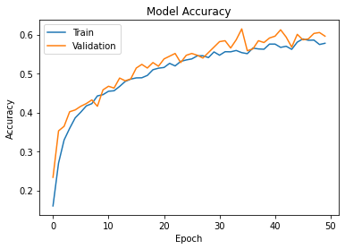

```python
plt.plot(history_vgg16.history['accuracy'])
plt.plot(history_vgg16.history['val_accuracy'])
plt.title('Model Accuracy')
plt.ylabel('Accuracy')
plt.xlabel('Epoch')
plt.legend(['Train', 'Validation'], loc='upper left')
plt.show()
```

```python
accuracy = new_model.evaluate(X_test_normalized, y_test_encoded, verbose=2)
```

```
15/15 - 1s - loss: 1.1853 - accuracy: 0.5958 - 730ms/epoch - 49ms/step
```

```python
# Here we would get the output as probablities for each category
y_pred=new_model.predict(X_test_normalized)
```

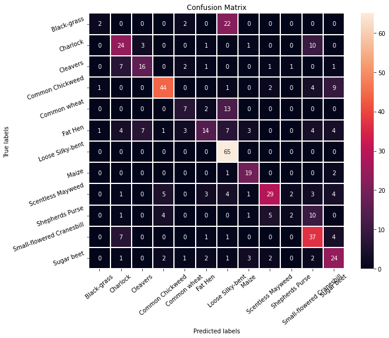

```python
# Obtaining the categorical values from y_test_encoded and y_pred
y_pred_arg=np.argmax(y_pred,axis=1)
y_test_arg=np.argmax(y_test_encoded,axis=1)

# Plotting the Confusion Matrix using confusion matrix() function which is also predefined tensorflow module
confusion_matrix = tf.math.confusion_matrix(y_test_arg,y_pred_arg)
f, ax = plt.subplots(figsize=(10, 8))
sns.heatmap(
    confusion_matrix,
    annot=True,
    linewidths=.4,
    fmt="d",
    square=True,
    ax=ax
)
# Setting the labels to both the axes
ax.set_xlabel('Predicted labels');ax.set_ylabel('True labels');
ax.set_title('Confusion Matrix');
ax.xaxis.set_ticklabels(list(enc.classes_),rotation=40)
ax.yaxis.set_ticklabels(list(enc.classes_),rotation=20)
plt.show()
```

```python
# Plotting the classification report
cr = classification_report(y_test_arg, y_pred_arg)
print(cr)
```

```
              precision    recall  f1-score   support

           0       0.50      0.08      0.13        26
           1       0.53      0.62      0.57        39
           2       0.62      0.55      0.58        29
           3       0.79      0.72      0.75        61
           4       0.47      0.32      0.38        22
           5       0.58      0.29      0.39        48
           6       0.57      1.00      0.72        65
           7       0.68      0.86      0.76        22
           8       0.74      0.56      0.64        52
           9       0.40      0.09      0.14        23
          10       0.53      0.74      0.62        50
          11       0.50      0.63      0.56        38

    accuracy                           0.60       475
   macro avg       0.58      0.54      0.52       475
weighted avg       0.60      0.60      0.56       475
```

## **Visualizing the prediction:**

```python
# Visualizing the predicted and correct label of images from test data
plt.figure(figsize=(2,2))
plt.imshow(X_test[2])
plt.show()
print('Predicted Label', enc.inverse_transform(new_model.predict((X_test_normalized[2].reshape(1,64,64,3)))))   # reshaping the input image as we are only trying to predict using a single image
print('True Label', enc.inverse_transform(y_test_encoded)[2])                                               # using inverse_transform() to get the output label from the output vector

plt.figure(figsize=(2,2))
plt.imshow(X_test[33])
plt.show()
print('Predicted Label', enc.inverse_transform(new_model.predict((X_test_normalized[33].reshape(1,64,64,3)))))  # reshaping the input image as we are only trying to predict using a single image
print('True Label', enc.inverse_transform(y_test_encoded)[33])                                              # using inverse_transform() to get the output label from the output vector

plt.figure(figsize=(2,2))
plt.imshow(X_test[36])
plt.show()
print('Predicted Label', enc.inverse_transform(new_model.predict((X_test_normalized[36].reshape(1,64,64,3)))))  # reshaping the input image as we are only trying to predict using a single image
print('True Label', enc.inverse_transform(y_test_encoded)[36])                                              # using inverse_transform() to get the output label from the output vector
```

```
Predicted Label ['Small-flowered Cranesbill']
True Label Small-flowered Cranesbill
```

```
Predicted Label ['Cleavers']
True Label Cleavers
```

```
Predicted Label ['Small-flowered Cranesbill']
True Label Shepherds Purse
```

## Conclusion

```python
pd.DataFrame({'Models':['Base CNN Model','CNN Model with Data Augumentation','CNN Model With Data Aug -different Filter sizes','Transfer Learning Model'],'Train Accuracy':['40%','79%','85%', '58'],'Validation Accuracy':['52%','82%','75%','60'],'Test Accuracy':['53%','81%','76%','60']})
```

|  | Models | Train Accuracy | Validation Accuracy | Test Accuracy |
| --- | --- | --- | --- | --- |
| 0 | Base CNN Model | 40% | 52% | 53% |
| 1 | CNN Model with Data Augumentation | 79% | 82% | 81% |
| 2 | CNN Model With Data Aug -different Filter sizes | 85% | 75% | 76% |
| 3 | Transfer Learning Model | 58 | 60 | 60 |